# Problema 1 Checkpoint 4

```r
library(dplyr)
library(ggplot2)
library(lubridate)
```

Para este checkpoint iremos responder as seguintes perguntas:

#### Quem são os deputados que mais gastaram com comida em apenas 1 refeição?

#### Os diferentes tipos de despesa se comportam de forma parecida ao decorrer de um mês?

Iniciaremos agora com a primeira:

```r
dados <- read.csv("ano-atual.csv")
```

Vamos ver qual o período de dados que temos:

```r
summary(dados$numAno)
```

```
##    Min. 1st Qu.  Median    Mean 3rd Qu.    Max.
##    2016    2016    2016    2016    2016    2016
```

```r
summary(dados$numMes)
```

```
##    Min. 1st Qu.  Median    Mean 3rd Qu.    Max.
##   1.000   2.000   3.000   3.297   4.000   7.000
```

Vemos que nossos dados são apenas de 2016 e temos meses entre janeiro (1) e julho (7).

Vamos ver qual o valor que os deputados gastam no geral:

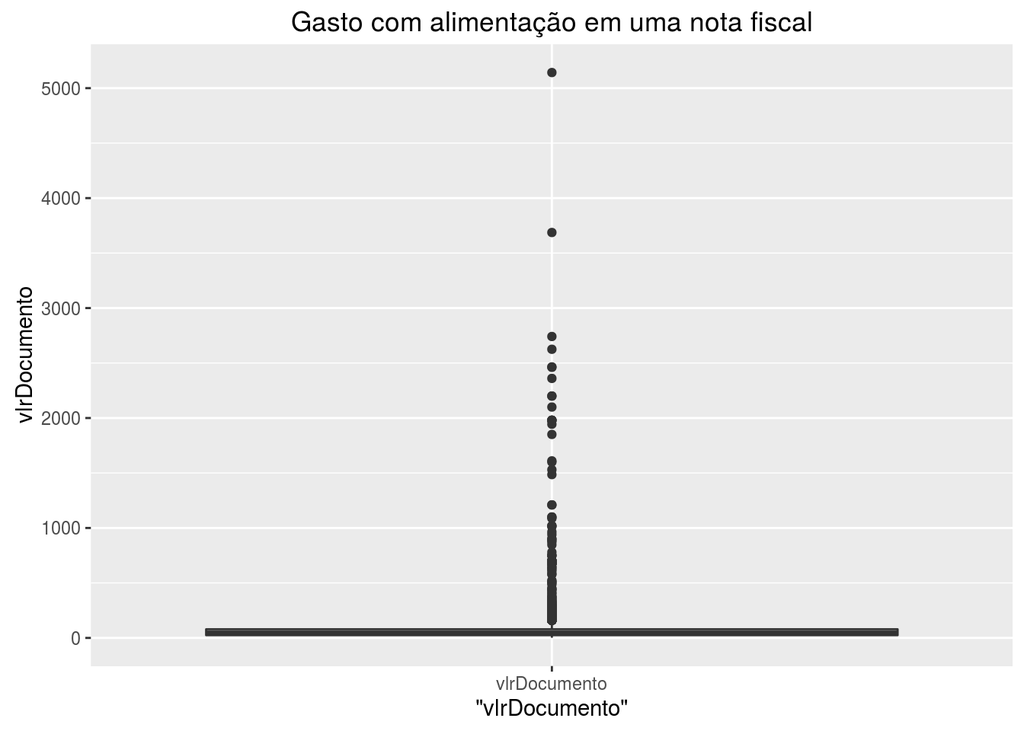

```r
dados.alimentacao <- dados %>%
  filter(txtDescricao == "FORNECIMENTO DE ALIMENTAÇÃO DO PARLAMENTAR")

ggplot(dados.alimentacao, aes(x = "vlrDocumento", y = vlrDocumento)) +
  geom_boxplot() +
  ggtitle("Gasto com alimentação em uma nota fiscal")
```

```r
summary(dados.alimentacao$vlrDocumento)
```

```
##    Min. 1st Qu.  Median    Mean 3rd Qu.    Max.
##    1.50   25.00   47.30   65.57   79.00 5142.00
```

Temos 13321 observações em que o valor da nota fiscal é referente a alimentação, onde o valor mínimo é 1.5 e o máximo é 5142, 75% dos dados estão abaixo de 79 e a mediana é 47.3.

Vamos ver a distribuição dos dados:

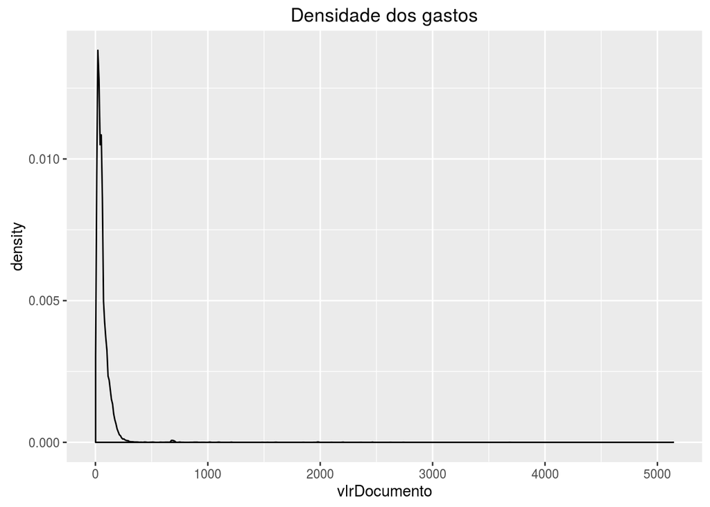

```r
ggplot(dados.alimentacao, aes(x = vlrDocumento)) +
  geom_density() +
  ggtitle("Densidade dos gastos")
```

Vemos que a maioria dos valores de alimentação realmente estão bem concentrados, mas existe uma pequena cocentração em cerca de R$700,00.

Vamos ver os 20 deputados que mais gastaram em apenas uma refeição:

```r
dados.alimentacao.exorbitantes <- dados.alimentacao %>%
  arrange(desc(vlrDocumento)) %>%
  filter(row_number() <= 20)

dados.alimentacao.exorbitantes %>% select(sgPartido, txNomeParlamentar, vlrDocumento) %>% head()
```

```
##   sgPartido txNomeParlamentar vlrDocumento
## 1      <NA>   LIDERANÇA DO PT      5142.25
## 2      <NA> LIDERANÇA DO PSDB      3687.50
## 3      <NA>   LIDERANÇA DO PT      2741.65
## 4      <NA>   LIDERANÇA DO PT      2625.45
## 5      <NA>   LIDERANÇA DO PT      2464.95
## 6      PSDB      JOÃO CASTELO      2461.31
```

Vemos que dos primeiros 6 que mais gastam, 5 não tem nome atribuído e sim a liderança de um partido. Talvez isso represente quando um conjunto de parlamentares fizeram uma refeição juntos.

Vamos ver agora apenas os que não representam a liderança (onde sgPartido é NA), mas apenas um parlamentar:

```r
dados.alimentacao.exorbitantes <- dados.alimentacao.exorbitantes <- dados.alimentacao %>%
  arrange(desc(vlrDocumento)) %>%
  filter(!is.na(sgPartido)) %>%
  filter(row_number() <= 20)

dados.alimentacao.exorbitantes %>% select(sgPartido, txNomeParlamentar, vlrDocumento, datEmissao)
```

```
##    sgPartido     txNomeParlamentar vlrDocumento          datEmissao
## 1       PSDB          JOÃO CASTELO      2461.31 2016-02-01T00:00:00
## 2       PSDB          JOÃO CASTELO      2360.50 2016-06-03T00:00:00
## 3       PSDB          JOÃO CASTELO      1944.00 2016-04-04T01:00:00
## 4        PPS         ARNALDO JORDY      1610.57 2016-02-03T00:00:00
## 5        PSD         EVANDRO ROMAN      1530.00 2016-04-11T00:00:00
## 6        PPS         ARNALDO JORDY      1485.79 2016-01-06T00:00:00
## 7        PSB      GONZAGA PATRIOTA       697.63 2016-06-08T00:00:00
## 8        PSD JOÃO PAULO KLEINÜBING       649.00 2016-04-07T00:00:00
## 9       PMDB           OSMAR TERRA       644.70 2016-04-02T00:00:00
## 10       PSD       FÁBIO MITIDIERI       630.07 2016-03-31T00:00:00
## 11       PPS          RUBENS BUENO       580.10 2016-04-27T00:00:00
## 12        PP            MAIA FILHO       523.50 2016-02-01T00:00:00
## 13       PPS          RUBENS BUENO       506.20 2016-05-17T00:00:00
## 14        PT  ADELMO CARNEIRO LEÃO       435.60 2016-03-03T00:00:00
## 15      PSDB         MARA GABRILLI       407.55 2016-04-07T00:00:00
## 16       PSD       FÁBIO MITIDIERI       367.50 2016-05-24T00:00:00
## 17       PPS          RUBENS BUENO       357.40 2016-04-06T00:00:00
## 18       PTN  FRANCISCO CHAPADINHA       345.00 2016-01-03T00:00:00
## 19        PR         MARCIO ALVINO       335.25 2016-04-04T00:00:00
## 20       PSD        RÔMULO GOUVEIA       317.36 2016-04-23T00:00:00
```

Vemos que o deputado JOÃO CASTELO foi o que mais gastou em apenas 1 valor de nota fiscal, mas vemos que cada nota fiscal dele foi paga no inicio de meses diferentes. Talvez isso seja um indício que não foi o valor gasto em apenas uma refeição, mas sim de todas as refeições de um mês.

Com isso nos questionamos com a seguinte pergunta:

#### Qual o deputado que mais gastou no ano de 2016 com refeições?

Veja que antes estávamos falando de maiores gastos em apenas 1 refeição e agora estamos falando de forma acumulada.

Veremos a seguir:

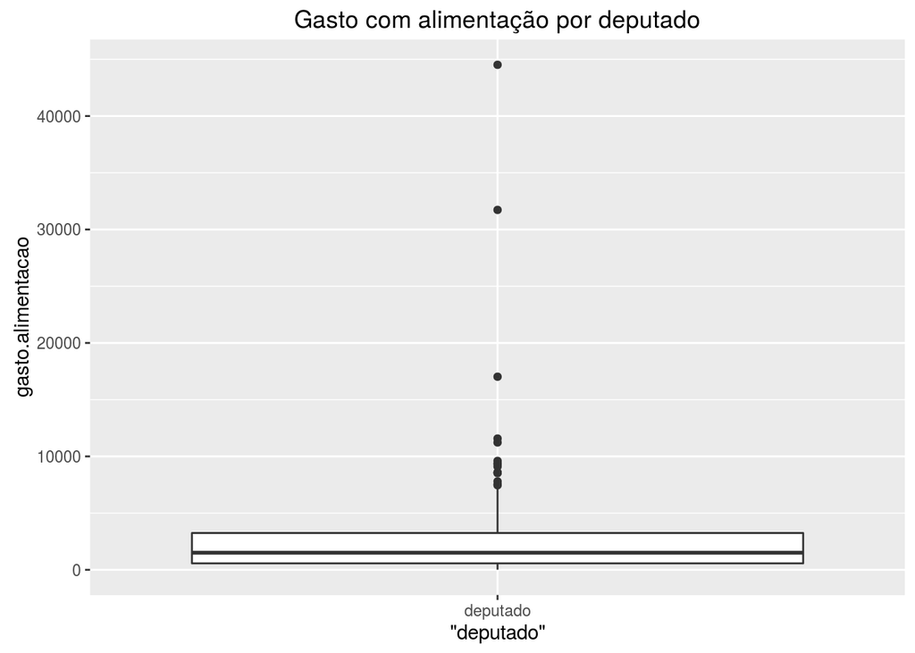

```r
gasto.alimentacao.deputados <- dados.alimentacao %>%
  group_by(txNomeParlamentar) %>%
  summarise(
      gasto.alimentacao = sum(vlrDocumento)
    )

ggplot(gasto.alimentacao.deputados, aes(x = "deputado", y = gasto.alimentacao)) +
  geom_boxplot() +
  ggtitle("Gasto com alimentação por deputado")
```

```r
summary(gasto.alimentacao.deputados$gasto.alimentacao)
```

```
##    Min. 1st Qu.  Median    Mean 3rd Qu.    Max.
##    11.1   572.3  1508.0  2453.0  3247.0 44520.0
```

Vemos que a mediana de gasto com alimentação dos deputados é de 1507.885 reais e 75% dos deputados gastam menos que 3247

```r
gasto.alimentacao.deputados %>%
  arrange(desc(gasto.alimentacao)) %>%
  head(10)
```

```
## Source: local data frame [10 x 2]
##
##           txNomeParlamentar gasto.alimentacao
##                      (fctr)             (dbl)
## 1         LIDERANÇA DO PSDB          44518.81
## 2           LIDERANÇA DO PT          31727.64
## 3            ROBERTO FREIRE          17024.98
## 4                      PROS          11575.09
## 5         LUIZ CARLOS RAMOS          11228.74
## 6              AFONSO MOTTA           9602.08
## 7        JOÃO MARCELO SOUZA           9399.16
## 8             MAJOR OLIMPIO           9299.05
## 9               ZECA DIRCEU           9109.48
## 10 ROGÉRIO PENINHA MENDONÇA           8580.27
```

Vemos que dos 10 deputados que mais gastam, 3 são junções de diversos deputados (LIDERANÇA DO PSDB, LIDERANÇA DO PT e PROS), mas o deputado que mais se destaca é ROBERTO FREIRE com um gasto parcial do ano de R$17024,98, cerca de 11,3 vezes maior que a mediana, em seguida LUIZ CARLOS RAMOS, com um gasto de R$11228,74, bem menor que o primeiro colocado.

Agora vamos ver como os diferentes tipos de despesa se comportam no decorrer de um mês:

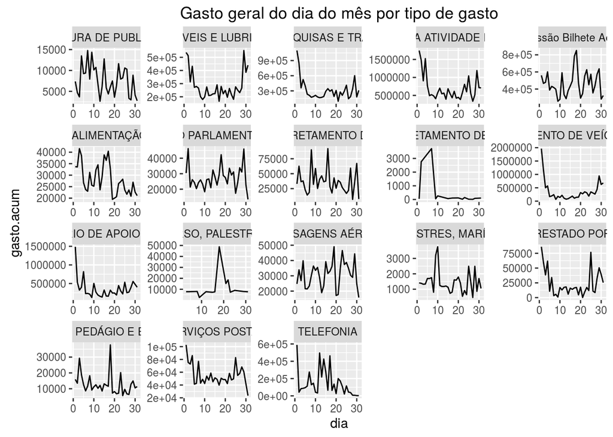

```r
gasto.por.dia.do.mes <- dados %>%
  mutate(
    dia = day(as.Date(datEmissao))
    ) %>%
  group_by(dia, txtDescricao) %>%
  summarise(
    gasto.acum = sum(vlrDocumento)
    )

ggplot(gasto.por.dia.do.mes, aes(x = dia, y = gasto.acum)) +
  geom_line() +
  facet_wrap(~ txtDescricao, scales = "free") +
  ggtitle("Gasto geral do dia do mês por tipo de gasto")
```

Algumas considerações que podemos fazer:

- Combustíveis e lubrificantes tem um maior gasto no início e no final do mês.
- Consultorias, pesquisas e trabalhos técnicos tem maior gasto no início do mês.
- Divulgação de atividade parlamentar parece ter um maior gasto no início do mês.
- Emissão de bilhetes aéreos é bastante variável, mas tem um pico perto da metade do mês.
- Fornecimento de alimentação do parlamentar tem um maior gasto antes do dia 20.
- Lotação ou fretamento de embarcações tem um grande gasto até o dia 10.
- Lotação ou fretamento de veículos automotores tem um gasto maior no início do mês, mas tem um certo aumento no final também.
- Manutenção de escritórios de apoio à atividade parlamentar tem um maior gasto no início do mês.
- Participação em curso, palestra ou evento similar tem um gasto grande entre o dai 15 e 20.
- Passagens terrestres, marítimas ou fluviais tem um pico no dia 10.
- Serviço de segurança prestado por empresa especializada tem um gasto maior no início e final do mês.
- Serviço de táxi, pedágio e estacionamento tem dois picos, perto do dia 4 e 17.
- Serviços postais tem um maior gasto tem um maior gasto até o dia 5.
- Telefonia tem um gasto maior no início e metade do mês.

Mas será que isso é realmente um padrão para todos os meses?

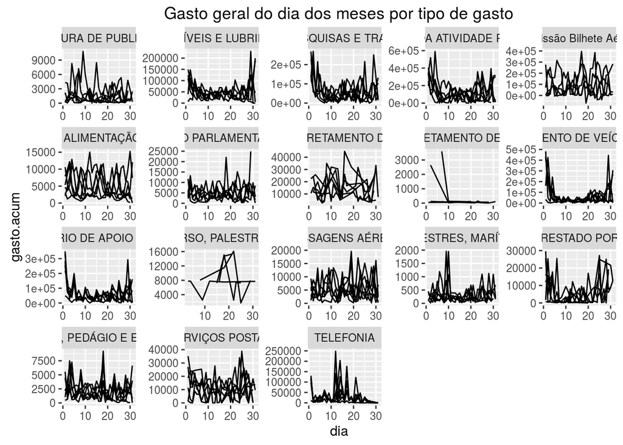

```r
gasto.por.dia.e.mes <- dados %>%
  mutate(
    dia = day(as.Date(datEmissao))
    ) %>%
  group_by(dia, numMes, txtDescricao) %>%
  summarise(
    gasto.acum = sum(vlrDocumento)
    )

ggplot(gasto.por.dia.e.mes, aes(x = dia, y = gasto.acum, group = numMes)) +
  geom_line() +
  facet_wrap(~ txtDescricao, scales = "free") +
  ggtitle("Gasto geral do dia dos meses por tipo de gasto")
```

Pelo visto a apenas algumas parecem seguir o padrão descrito acima, tais quais:

- Combustíveis e lubrificantes
- Consultoria, pesquisas e trabalhos técnicos
- Divulgação da atividade parlamentar
- Locação ou fretamento de veículos automotores
- Manutenção de escritório de apoio à atividade parlamentar
- Participação em curso, palestra ou evento similar
- Passagens terrestres, marítimas ou fluviais
- Serviço de segurança prestado por empresa especializada

Grande parte das despesas parecem ser dentro do esperado, algumas com um aumento no início ou no final do mês e algumas com um aumento no meio do mês também. Com isso, apenas alguns tipos de despesa se comportam de maneira parecida.

Algo que eu particularmente não esperava é que consultorias, pesquisas e trabalhos técnicos seguissem um padrão. O que nos leva a seguinte pergunta:

#### Qual o deputado que gasta mais com esse tipo de despesa (consultorias, pesquisas e trabalhos técnicos)?

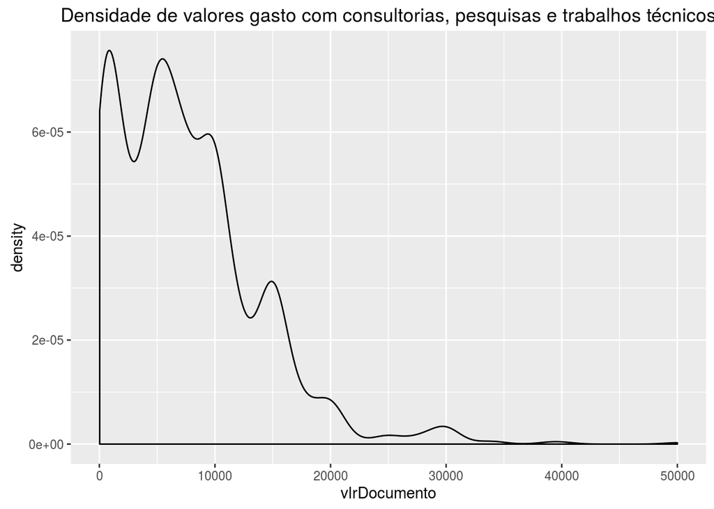

```r
dados.pesquisa <- dados %>%
  filter(txtDescricao == "CONSULTORIAS, PESQUISAS E TRABALHOS TÉCNICOS.")

ggplot(dados.pesquisa, aes(vlrDocumento)) +
  geom_density() +
  ggtitle("Densidade de valores gasto com consultorias, pesquisas e trabalhos técnicos")
```

Vemos que grande parte dos documentos tem valor menor que R$15000,00, mas algo estranho é ter um ligeiro pico em cerca de R$30000,00.

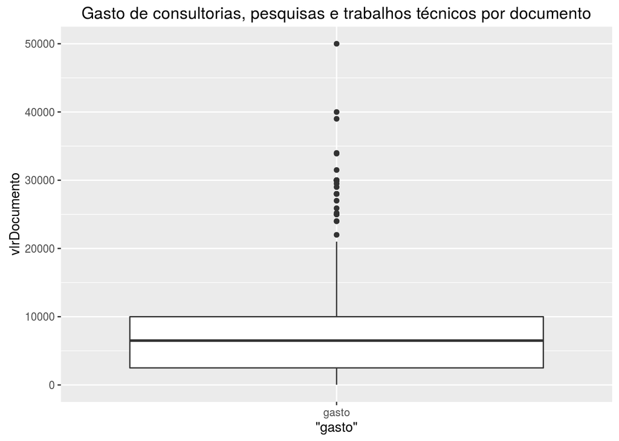

```r
ggplot(dados.pesquisa, aes(x = "gasto", y = vlrDocumento)) +
  geom_boxplot() +
  ggtitle("Gasto de consultorias, pesquisas e trabalhos técnicos por documento")
```

```r
summary(dados.pesquisa$vlrDocumento)
```

```
##    Min. 1st Qu.  Median    Mean 3rd Qu.    Max.
##      30    2500    6500    7464   10000   50000
```

```r
dados.pesquisa %>%
  arrange(desc(vlrDocumento)) %>%
  select(sgPartido, txNomeParlamentar, vlrDocumento) %>%
  head(15)
```

```
##    sgPartido     txNomeParlamentar vlrDocumento
## 1        PTB       PEDRO FERNANDES        50000
## 2      PCdoB        DANIEL ALMEIDA        40000
## 3         PP        RICARDO BARROS        39000
## 4        PSB         CÉSAR MESSIAS        34000
## 5       PMDB         FLAVIANO MELO        33900
## 6        PSB         JOSÉ REINALDO        31500
## 7         PP         FRANKLIN LIMA        30000
## 8        PSD       HEULER CRUVINEL        30000
## 9        PRB           JONY MARCOS        30000
## 10        PP                MACEDO        30000
## 11      PMDB          MARX BELTRÃO        30000
## 12      PMDB          MARX BELTRÃO        30000
## 13     PCdoB PROFESSORA MARCIVANIA        30000
## 14        PR     VICENTINHO JÚNIOR        30000
## 15        PR     VICENTINHO JÚNIOR        30000
```

Vemos que alguns nomes como MARX BELTRÃO e VICENTINHO JÚNIOR se repetem mais de uma vez. Então vejamos o total gasto por deputado no ano de 2016:

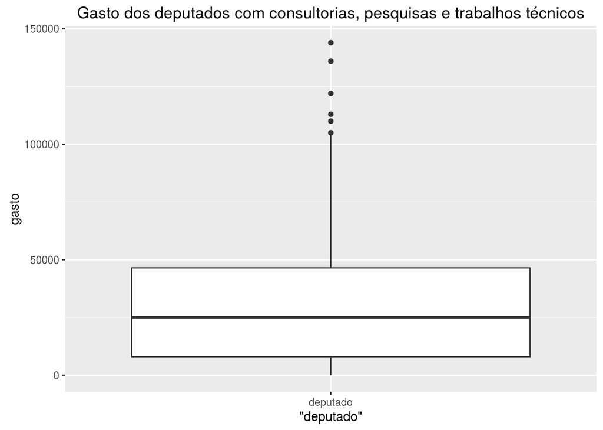

```r
dados.pesquisa.por.deputado <- dados.pesquisa %>%
  group_by(txNomeParlamentar, sgPartido) %>%
  summarise(
    gasto = sum(vlrDocumento)
    )

ggplot(dados.pesquisa.por.deputado, aes("deputado", gasto)) +
  geom_boxplot() +
  ggtitle("Gasto dos deputados com consultorias, pesquisas e trabalhos técnicos")
```

```r
summary(dados.pesquisa.por.deputado$gasto)
```

```
##    Min. 1st Qu.  Median    Mean 3rd Qu.    Max.
##      50    8000   25000   30440   46500  144000
```

Vemos que os deputados gastam entre R$50,00 e R$144000,00, tendo uma mediana de gasto de R$25000,00. 75% dos deputados gastam menos que R$46500,00. Vamos ver quem são os deputados que mais gastam:

```r
dados.pesquisa.por.deputado %>%
  ungroup() %>%
  arrange(desc(gasto)) %>%
  head()
```

```
## Source: local data frame [6 x 3]
##
##   txNomeParlamentar sgPartido  gasto
##              (fctr)    (fctr)  (dbl)
## 1     DOMINGOS NETO       PSD 144000
## 2     VICTOR MENDES       PSD 136000
## 3 VICENTINHO JÚNIOR        PR 122000
## 4     ROBERTO SALES       PRB 113000
## 5  ELMAR NASCIMENTO       DEM 110000
## 6        MAIA FILHO        PP 105000
```

Vemos que o deputado com maior gasto é DOMINGOS NETO, onde o mesmo teve gasto mais de 3 vezes maior que a mediana.